# CleaningMortality

Ainsley Lotito

2025-11-19

## Mortality Data

We will start by cleaning the mortality dataset from the national park service. Let’s start by reading in the data and looking at the columns.

```r
mortality <- read_csv("../data/NPS-Mortality-Data-CY2007-to-CY2024-Released-August-2024.csv", col_names = TRUE)
```

[output not shown]

```r
head(mortality)
```

```
## # A tibble: 6 × 9
##   `Incident Date` `Park Name`     `Cause of Death` Cause of Death Group…¹ Intent
##   <chr>           <chr>           <chr>            <chr>                  <chr>
## 1 1/1/07          Glen Canyon Na… Undetermined     Undetermined           Undet…
## 2 1/22/07         Golden Gate Na… Drowning         Drowning               Unint…
## 3 1/22/07         Golden Gate Na… Undetermined     Undetermined           Undet…
## 4 1/29/07         Natchez Trace … Motor Vehicle C… Motor Vehicle Crash    Unint…
## 5 1/29/07         Natchez Trace … Motor Vehicle C… Motor Vehicle Crash    Unint…
## 6 2/7/07          Gateway Nation… Undetermined     Undetermined           Undet…
## # ℹ abbreviated name:
## #   ¹`Cause of Death Group \n(Used in the NPS Mortality Dashboard)`
## # ℹ 4 more variables: Outcome <chr>, Sex <chr>, `Age Range` <chr>,
## #   Activity <chr>
```

```r
dim(mortality)
```

```
## [1] 4635    9
```

Mortality read in correctly, we have 9 variables and 4,635 observations.

We need to reclassify some variables, rename them, and reclassify not reported information as NA.

```r
mortality <- mortality %>%
  mutate(incident_date = mdy(`Incident Date`),
         year = year(incident_date)) %>% #creating year variable to aid with merging with other df
  rename(park = `Park Name`,
         death_cause = `Cause of Death`,
         death_group = 4,
         age_range = `Age Range`) %>%
  select(-1,)
colnames(mortality) <- tolower(colnames(mortality))
head(mortality)
```

```
## # A tibble: 6 × 10
##   park           death_cause death_group intent outcome sex   age_range activity
##   <chr>          <chr>       <chr>       <chr>  <chr>   <chr> <chr>     <chr>
## 1 Glen Canyon N… Undetermin… Undetermin… Undet… Fatal … Male  65+       Not Rep…
## 2 Golden Gate N… Drowning    Drowning    Unint… Fatal … Male  Not Repo… Vessel …
## 3 Golden Gate N… Undetermin… Undetermin… Undet… Fatal … Male  Not Repo… Vessel …
## 4 Natchez Trace… Motor Vehi… Motor Vehi… Unint… Fatal … Fema… 15-24     Driving
## 5 Natchez Trace… Motor Vehi… Motor Vehi… Unint… Fatal … Fema… 45-54     Driving
## 6 Gateway Natio… Undetermin… Undetermin… Undet… Fatal … Male  Not Repo… Not Rep…
## # ℹ 2 more variables: incident_date <date>, year <dbl>
```

We are going to explore missing data by reclassifying “Undetermined” and “Not reported” data in a new dataframe and look through some patterns to see if specific causes of death have higher proportions of missing data.

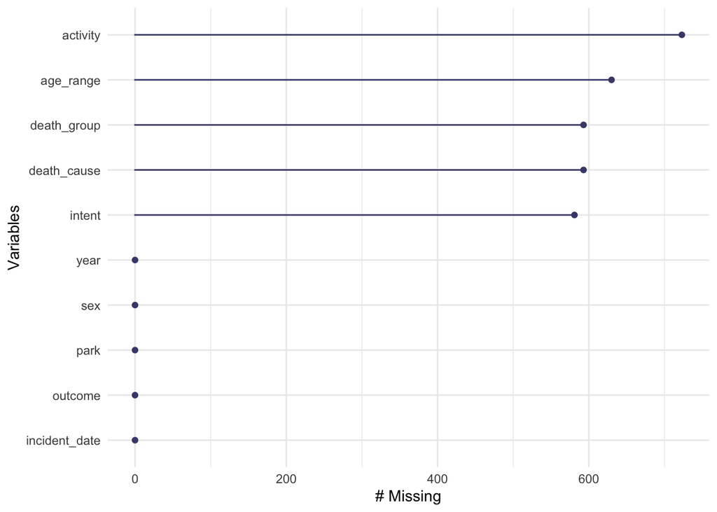

```r
#changing "Not Reported" to be NA in different dataset
mortality_miss <- mortality %>%
  mutate(across(c(intent, death_group, death_cause),
                ~ na_if(., "Undetermined")),
         across(c(age_range, activity),
                ~ na_if(., "Not Reported")))
gg_miss_var(mortality_miss)
```

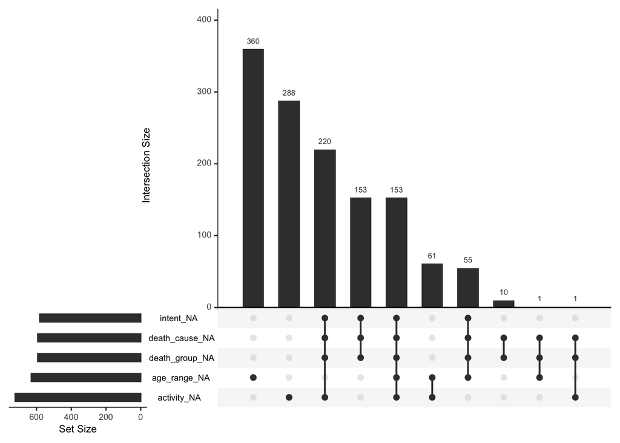

```r
gg_miss_upset(mortality_miss)
```

```r
mortality_miss %>%
  mutate(missing = is.na(intent) & is.na(age_range) & is.na(activity)) %>%
  group_by(death_cause, missing) %>%
  count()
```

```
## # A tibble: 48 × 3
## # Groups:   death_cause, missing [48]
##    death_cause           missing     n
##    <chr>                 <lgl>   <int>
##  1 Aircraft Incident     FALSE      31
##  2 Aircraft incident     FALSE      46
##  3 Altitude              FALSE       1
##  4 Asphyxiation          FALSE       7
##  5 Avalanche             FALSE      41
##  6 Bicycle only crash    FALSE      23
##  7 Collapsing earth/sand FALSE       2
##  8 Drowning              FALSE     864
##  9 Electrocution         FALSE       4
## 10 Fall                  FALSE     505
## # ℹ 38 more rows
```

```r
mortality_miss %>%
  mutate(missing =  is.na(age_range)) %>%
  group_by(death_cause, missing) %>%
  count()
```

```
## # A tibble: 72 × 3
## # Groups:   death_cause, missing [72]
##    death_cause        missing     n
##    <chr>              <lgl>   <int>
##  1 Aircraft Incident  FALSE      15
##  2 Aircraft Incident  TRUE       16
##  3 Aircraft incident  FALSE      38
##  4 Aircraft incident  TRUE        8
##  5 Altitude           FALSE       1
##  6 Asphyxiation       FALSE       7
##  7 Avalanche          FALSE      30
##  8 Avalanche          TRUE       11
##  9 Bicycle only crash FALSE      20
## 10 Bicycle only crash TRUE        3
## # ℹ 62 more rows
```

```r
#add on later to summarize by proportions and which have highest mortality counts
```

```r
#seeing how many obs we are cutting out

 mortality %>%
  filter(year %in% c(2020:2024)) %>%
   nrow()
```

```
## [1] 1373
```

```r
#we are cutting out 2017 ()

mortality <- mortality %>%
  filter(year %in% c(2007:2019))
dim(mortality)
```

```
## [1] 3262   10
```

```r
unique(mortality$year)
```

```
##  [1] 2007 2008 2009 2010 2011 2012 2013 2014 2015 2016 2017 2018 2019
```

We now have 3,262 observations (it removed 1,373 obsevations)

### Saving cleaned dataset

We are going to save the cleaned mortality df to our data folder so it can be joined with the National Park dataframe for future analysis.

```r
write.csv(mortality, "../data/mortality_clean.csv", row.names = TRUE)
```

# Exploratory analysis

We are interested in looking at patterns of mortality in our data before we join the datasets to think through maps that would be interesting. First, we are going to plan out a chloropleth map that organizes mortality counts in the parks over the whole period (2007-2019) and by each year individually.

We will start by analyzing this with the summarize function first to look at which parks have the highest mortality counts over each year.

```r
#raw count
mortality %>%
  group_by(park) %>%
  summarize(mortality_count = n()) %>%
  arrange(desc(mortality_count))
```

```
## # A tibble: 186 × 2
##    park                                  mortality_count
##    <chr>                                           <int>
##  1 Lake Mead National Recreation Area                230
##  2 Grand Canyon National Park                        155
##  3 Yosemite National Park                            150
##  4 Blue Ridge Parkway                                128
##  5 Natchez Trace Parkway                             122
##  6 Golden Gate National Recreation Area              120
##  7 Glen Canyon National Recreation Area               99
##  8 Great Smoky Mountains National Park                98
##  9 New River Gorge National River                     71
## 10 Sequoia & Kings Canyon National Parks              71
## # ℹ 176 more rows
```

```r
#top 3 by year
mortality %>%
  group_by(park, year) %>%
  summarize(mortality_count = n(), .groups = "drop") %>%
  group_by(year) %>%
  slice_max(mortality_count, n = 3)
```

```
## # A tibble: 46 × 3
## # Groups:   year [13]
##    park                                         year mortality_count
##    <chr>                                       <dbl>           <int>
##  1 Glen Canyon National Recreation Area         2007              10
##  2 Lake Mead National Recreation Area           2007               9
##  3 Mount Rainier National Park                  2007               9
##  4 Lake Mead National Recreation Area           2008              11
##  5 Delaware Water Gap National Recreation Area  2008               7
##  6 Golden Gate National Recreation Area         2008               7
##  7 Lake Mead National Recreation Area           2009              17
##  8 Golden Gate National Recreation Area         2009              11
##  9 Grand Canyon National Park                   2009              11
## 10 Lake Mead National Recreation Area           2010              22
## # ℹ 36 more rows
```

We also want to look into the causes of death and how those contribute to mortality counts.

```r
#raw count
mortality %>%
  group_by(death_group) %>%
  summarize(mortality_count = n()) %>%
  arrange(desc(mortality_count))
```

```
## # A tibble: 15 × 2
##    death_group                            mortality_count
##    <chr>                                            <int>
##  1 Drowning                                           715
##  2 Motor Vehicle Crash                                573
##  3 Fall                                               396
##  4 Suicide                                            381
##  5 Undetermined                                       338
##  6 Medical - During physical activity                 220
##  7 Environmental                                      193
##  8 Medical - Not during physical activity             179
##  9 Other Transportation                               127
## 10 Poisoning                                           43
## 11 Medical - Unknown                                   39
## 12 Homicide                                            25
## 13 Other                                               23
## 14 Wildlife Incident                                    8
## 15 Legal Intervention                                   2
```

```r
#top 3 by year
mortality %>%
  group_by(death_group, year) %>%
  summarize(mortality_count = n(), .groups = "drop") %>%
  group_by(year) %>%
  slice_max(mortality_count, n = 3)
```

```
## # A tibble: 40 × 3
## # Groups:   year [13]
##    death_group          year mortality_count
##    <chr>               <dbl>           <int>
##  1 Drowning             2007              51
##  2 Motor Vehicle Crash  2007              35
##  3 Fall                 2007              30
##  4 Drowning             2008              46
##  5 Motor Vehicle Crash  2008              32
##  6 Fall                 2008              22
##  7 Drowning             2009              60
##  8 Motor Vehicle Crash  2009              30
##  9 Fall                 2009              21
## 10 Drowning             2010              56
## # ℹ 30 more rows
```

```r
#let's do it again by age group
#raw count
mortality %>%
  group_by(death_group, age_range) %>%
  summarize(mortality_count = n()) %>%
  arrange(desc(mortality_count))
```

```
## # A tibble: 102 × 3
## # Groups:   death_group [15]
##    death_group                            age_range    mortality_count
##    <chr>                                  <chr>                  <int>
##  1 Drowning                               15-24                    154
##  2 Undetermined                           Not Reported             125
##  3 Medical - During physical activity     65+                      100
##  4 Drowning                               25-34                     99
##  5 Drowning                               45-54                     98
##  6 Drowning                               Not Reported              95
##  7 Motor Vehicle Crash                    55-64                     93
##  8 Motor Vehicle Crash                    45-54                     92
##  9 Medical - Not during physical activity 65+                       89
## 10 Motor Vehicle Crash                    15-24                     87
## # ℹ 92 more rows
```

```r
#top 3 by year
mortality %>%
  group_by(death_group, age_range, year) %>%
  summarize(mortality_count = n(), .groups = "drop") %>%
  group_by(year) %>%
  slice_max(mortality_count, n = 3)
```

```
## # A tibble: 47 × 4
## # Groups:   year [13]
##    death_group         age_range     year mortality_count
##    <chr>               <chr>        <dbl>           <int>
##  1 Drowning            15-24         2007              10
##  2 Fall                25-34         2007              10
##  3 Motor Vehicle Crash Not Reported  2007               9
##  4 Drowning            15-24         2008              10
##  5 Drowning            45-54         2008               8
##  6 Motor Vehicle Crash 15-24         2008               8
##  7 Motor Vehicle Crash Not Reported  2008               8
##  8 Drowning            Not Reported  2009              11
##  9 Drowning            15-24         2009              10
## 10 Drowning            25-34         2009              10
## # ℹ 37 more rows
```

```r
#top 3 by park
mortality %>%
  group_by(death_group, age_range, park) %>%
  summarize(mortality_count = n(), .groups = "drop") %>%
  group_by(death_group,age_range) %>%
  slice_max(mortality_count, n = 1)
```

```
## # A tibble: 197 × 4
## # Groups:   death_group, age_range [102]
##    death_group   age_range    park                               mortality_count
##    <chr>         <chr>        <chr>                                        <int>
##  1 Drowning      0-14         Indiana Dunes National Park                      5
##  2 Drowning      15-24        Lake Mead National Recreation Area              22
##  3 Drowning      25-34        Lake Mead National Recreation Area              17
##  4 Drowning      35-44        Lake Mead National Recreation Area              12
##  5 Drowning      45-54        Lake Mead National Recreation Area              18
##  6 Drowning      55-64        Cape Hatteras National Seashore                  8
##  7 Drowning      65+          Cape Hatteras National Seashore                  8
##  8 Drowning      Not Reported New River Gorge National River                  12
##  9 Environmental 0-14         Big Thicket National Preserve                    1
## 10 Environmental 0-14         Chattahoochee River National Recr…               1
## # ℹ 187 more rows
```

```r
library(plotly)

#starting simple plot
cod_count <- mortality %>%
  group_by(death_group) %>%
  summarize(mortality_count = n(), .groups = "drop")

cod_plot <-plot_ly(
  data = cod_count,
  x = ~death_group,
  y = ~mortality_count,
  name = "Death Counts by Cause of Death",
  type = "bar"
)
cod_plot <- cod_plot %>% layout(yaxis = list(title = 'Mortality Count'), barmode = 'group') %>% layout(xaxis = list(title = 'Cause of Death'), barmode = 'group')

cod_plot
```

[interactive chart not shown]

We can probably condense “Legal Intervention” in the Other category since there are only 2 deaths over the entire period. These deaths are due to people being killed or dying as a result of injuries from a law enforcement officer.

We are going to condense the Medical categories together, since there is no information about whether the PA caused the medical event to occur, just that it happened simultaneously.

I am going to create a new variable that has these cleaned up, and then summarize before creating a new basic plot then moving on with more details. I am also going to make an even BROADER categorization, which removes some information but will be useful in figuring out which parks have larger general trends for mortality causes.

```r
mortality <- mortality %>%
  mutate(cod = case_when(
    # Medical
    death_group %in% c("Medical - Not during physical activity", "Medical - Unknown", "Medical - During physical activity") ~ "Medical",

    #Condensing Legal Intervention with Other
    death_group %in% c("Legal Intervention", "Other") ~ "Other",

    #All other categories Consistent
    TRUE ~ death_group #keep original death_group codings
  ),
  cod_broad = case_when(
      # Medical
      death_group %in% c(
        "Medical - During physical activity",
        "Medical - Not during physical activity",
        "Medical - Unknown"
      ) ~ "Medical",

      # Unintentional Injury - Water
      death_group == "Drowning" ~ "Unintentional - Water",

      # Unintentional Injury - Falls
      death_group == "Fall" ~ "Unintentional - Fall",

      # Transportation
      death_group %in% c("Motor Vehicle Crash", "Other Transportation") ~
        "Unintentional - Transportation",

      # Environmental & Wildlife
      death_group %in% c("Environmental", "Wildlife Incident") ~
        "Unintentional - Environmental",

      # Poisoning
      death_group == "Poisoning" ~ "Unintentional - Poisoning",

      # Intentional
      death_group == "Suicide" ~ "Intentional - Suicide",
      death_group == "Homicide" ~ "Intentional - Homicide",
      death_group == "Legal Intervention" ~ "Intentional - Homicide",

      # Other / Undetermined
      death_group %in% c("Other", "Undetermined") ~ "Other / Undetermined",

      TRUE ~ "Other / Undetermined"
    ))
```

Now, let’s create two new plots with these new categorizations:

```r
#COD
#starting simple plot
cod_count <- mortality %>%
  group_by(cod) %>%
  summarize(mortality_count = n(), .groups = "drop")

cod_plot <-plot_ly(
  data = cod_count,
  x = ~cod,
  y = ~mortality_count,
  name = "Death Counts by Cause of Death",
  type = "bar"
)
cod_plot <- cod_plot %>% layout(yaxis = list(title = 'Mortality Count'), barmode = 'group') %>% layout(xaxis = list(title = 'Cause of Death'), barmode = 'group')

cod_plot
```

[interactive chart not shown]

```r
#COD Broad
cod_broad_count <- mortality %>%
  group_by(cod_broad) %>%
  summarize(mortality_count = n(), .groups = "drop")

cod_broad_count <-plot_ly(
  data = cod_broad_count,
  x = ~cod_broad,
  y = ~mortality_count,
  name = "Death Counts by Cause of Death",
  type = "bar"
)
cod_broad_count <- cod_broad_count %>% layout(yaxis = list(title = 'Mortality Count'), barmode = 'group') %>% layout(xaxis = list(title = 'Cause of Death'), barmode = 'group')

cod_broad_count
```

[interactive chart not shown]

Now, I want to explore how cause of death changes based on some other facets. I want to explore how the distribution of deaths by age group change depending on COD (facet by COD, bars are age groups).  
I will make a plot for the first COD categorization first:

```r
#COD simple

#creating df with needed data
cod_by_age <- mortality %>%
  group_by(cod, age_range) %>%
  summarize(mortality_count = n(), .groups = "drop")

#going to reorder by cods with most deaths in general
cod_order <- cod_by_age %>%
  group_by(cod) %>%
  summarize(total_mort = sum(mortality_count)) %>%
  arrange(desc(total_mort))
cod_by_age$cod <- factor(cod_by_age$cod, levels = cod_order$cod)


#plotting
p_age <- ggplot(cod_by_age, aes(x = age_range, y = mortality_count)) +
  geom_col() +
  facet_wrap(~ cod, ncol = 2, scales = "free_x") +
  labs(title = "Death Counts by Cause of Death and Age",
       x = "Victim Age Group",
       y = "Death Count") +
  theme_classic() +
  theme(plot.title = element_text(hjust = 0.5, face = "bold")) +
    scale_y_continuous(breaks = c(seq(from = 0, to = 200, by = 25)
)) +
  theme(axis.text.x = element_text (size = 8),
        strip.text = element_text(size = 11, face = "bold"))

cod_by_age_plot <- ggplotly(p_age)
cod_by_age_plot
```

[interactive chart not shown]

```r
#look into shiny embedding https://testing-apps.shinyapps.io/flexdashboard-shiny-embedding/
```

This is the plot option that we decided to put in our flexdashboard, so there is some extra code cleaning it up. I also am going to continue exploration below, but we didn’t end up using any of the following maps.

Next, using the broad COD categorization:

```r
#COD broad

#creating df with needed data
codb_by_age <- mortality %>%
  group_by(cod_broad, age_range) %>%
  summarize(mortality_count = n(), .groups = "drop")

#plotting
p_ageb <- ggplot(codb_by_age, aes(x = age_range, y = mortality_count)) +
  geom_col() +
  facet_wrap(~ cod_broad, ncol = 2) +
  labs(title = "Death Counts by Cause of Death and Age",
       x = "Victim Age Group",
       y = "Death Count") +
  theme_classic() +
  theme(plot.title = element_text(hjust = 0.5, face = "bold"))

codb_by_age_plot <- ggplotly(p_ageb)
codb_by_age_plot
```

[interactive chart not shown]

```r
cod_park <- mortality %>%
  group_by(cod, park, age_range) %>%
  summarize(mortality_count = n(), .groups = "drop") %>%
  group_by(cod, park) %>%
  slice_max(mortality_count, n = 3)

p <- ggplot(cod_park, aes(
  x = age_range,
  y = mortality_count,
  fill = park,
  text = paste("Park:", park,
               "<br>Age Range:", age_range,
               "<br>Count:", mortality_count)
)) +
  geom_col(position = "dodge") +
  facet_wrap(~cod) +
  labs(x = "Age Range", y = "Mortality Count") +
  theme_bw()

ggplotly(p, tooltip = "text")
```

[interactive chart not shown]